# Germline Variant Analysis Tutorial

Anastasiia Korosteleva

2026-02-19

## Introduction

This tutorial introduces **germline variant analysis** using targeted panel sequencing data. We explore real-world samples from the study:

**Clinical impact of a targeted next-generation sequencing gene panel for autoinflammation and vasculitis** (Omoyinmi et al., PLoS ONE)

We’ll analyze annotated variants from three example patients:

- **Patient 2:** chr10-70598687-G>C
- **Patient 23:** PTEN c.650T>G (p.Val217Gly)
- **Patient 25:** RNF213 c.12034T>C (p.Cys4012Arg)

## Nextflow

```bash
NXF_VER=24.04.4 nextflow run nf-core/sarek -r 3.4.2 \
-profile docker \
--input /samplesheet.csv \
--outdir /results \
--genome GATK.GRCh38 \
--wes \
--save_mapped \
--save_output_as_bam \
--multiqc_title tutorial_example2 \
--trim_fastq  \
--tools mutect2,manta,vep \
-bg  \
-resume
```

## Objectives

By the end of this session, you will be able to:

1. Load and explore annotated VCF files.
2. Extract and filter variants by impact or gene.
3. Visualize the variant consequence spectrum.
4. Interpret example variants in a clinical context.

## Setup

```r
library(data.table)
library(dplyr)
library(stringr)
library(tidyr)
library(ggplot2)
```

## Task 0: Explore raw VCF file and VEP

1. Explore the file format via sublime/text-reader
2. Go to https://www.ensembl.org/Tools/VEP and explore possible fields (our reference is GRCh38.p14)
3. Work with pre-loaded `VEP.ann.vcf` or your own
4. Server-version of VEP gives more plugins and freedom in use

## Task 1: Load VEP-Annotated VCF as Table

```r
vcf_path <- "/home/akorosteleva/tutorial/example_1/Patient_2.haplotypecaller.filtered_VEP.ann.vcf"

# Read VCF as a plain table (skip header lines; adjust if needed)
vcf_data <- fread(vcf_path, skip = 3401)

# Save as CSV
csv_out <- "/home/akorosteleva/tutorial/example_1/Patient_2.vep_annotated.csv"
fwrite(vcf_data, csv_out)

head(vcf_data)
```

```
##    #CHROM      POS          ID    REF    ALT    QUAL FILTER
##    <char>    <int>      <char> <char> <char>   <num> <char>
## 1:   chr1 11029957  rs79393073      A      G  157.64   PASS
## 2:   chr1 11030230  rs61735593      C      T 1689.64   PASS
## 3:   chr1 11031148  rs17409276      G      A  250.97   PASS
## 4:   chr1 11034700  rs70977538      G     GA  475.60   PASS
## 5:   chr1 11034982   rs6695096      C      T  914.64   PASS
## 6:   chr1 11037490 rs116685064      C      A  620.64   PASS
##                                                                                                                                                                                                                                                                                                          …
##                                                                                                                                                                                                                                                                                                          …
## 1:                                                                                                                                                                                                                                                                                                       …
## 2: AC=1;AF=0.500;AN=2;BaseQRankSum=-1.670;CNN_1D=-2.142;DB;DP=124;ExcessHet=0.0000;FS=0.662;MLEAC=1;MLEAF=0.500;MQ=60.00;MQRankSum=0.000;QD=13.63;ReadPosRankSum=1.321;SOR=0.621;CSQ=T|missense_variant|MODERATE|MASP2|ENSG00000009724|Transcript|ENST00000400897|protein_coding|10/11||||1275/2455|1243/…
## 3:                                                                                                                                                                                                                                                                                                       …
## 4:                                                                                                                                                                                                                                                                                                       …
## 5:                                                                                                                                                                                                                                                                                                       …
## 6:                                                                                                                                                                                                                                                                                      AC=1;AF=0.500;AN=…
##            FORMAT          Patient_2_Patient_2
##            <char>                       <char>
## 1: GT:AD:DP:GQ:PL        0/1:1,4:5:28:165,0,28
## 2: GT:AD:DP:GQ:PL 0/1:58,66:124:99:1697,0,1549
## 3: GT:AD:DP:GQ:PL        1/1:0,6:6:18:265,18,0
## 4: GT:AD:DP:GQ:PL    0/1:28,32:60:99:483,0,525
## 5: GT:AD:DP:GQ:PL   0/1:31,28:59:99:922,0,1121
## 6: GT:AD:DP:GQ:PL    0/1:19,17:36:99:628,0,747
```

## Task 2: Filter Damaging Variants

```r
vcf_csv <- read.csv(csv_out)

# Filter for likely damaging/pathogenic, excluding uncertain or benign
vcf_damaging <- vcf_csv %>%
  filter(grepl("damaging|pathogenic|High Impact", INFO, ignore.case = TRUE)) %>%
  filter(!str_detect(INFO, regex("uncertain_significance|benign", ignore_case = TRUE)))

dim(vcf_damaging)
```

```
## [1]  4 10
```

## Task 3: Visualize Variant Consequences

> Note: VEP writes the CSQ header in the VCF header (not read by `fread` here).  
> In this tutorial we assume the **second CSQ field** corresponds to `Consequence`.

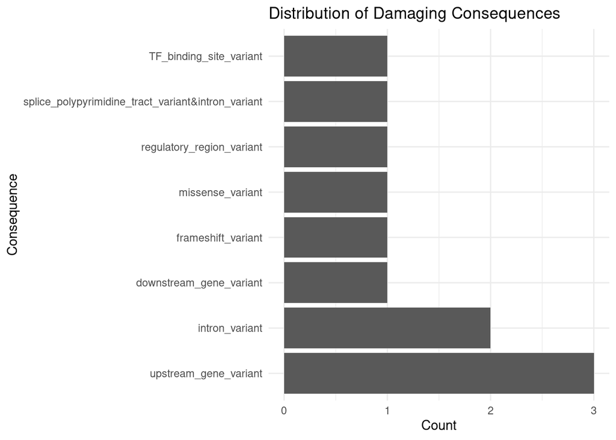

```r
# Extract CSQ field entries (comma-separated transcript annotations)
extract_csq_entries <- function(info_str) {
  parts <- strsplit(info_str, ";", fixed = TRUE)[[1]]
  csq_entry <- grep("^CSQ=", parts, value = TRUE)
  if (length(csq_entry) == 0) return(character(0))
  strsplit(sub("^CSQ=", "", csq_entry), ",", fixed = TRUE)[[1]]
}

# From each CSQ entry, take field #2 = Consequence (pipe-separated fields)
extract_consequence <- function(csq_entry) {
  fields <- strsplit(csq_entry, "\\|")[[1]]
  if (length(fields) >= 2) fields[2] else NA_character_
}

csq_data <- vcf_damaging$INFO %>%
  lapply(extract_csq_entries) %>%
  unlist() %>%
  lapply(extract_consequence) %>%
  unlist()

csq_df <- data.frame(Consequence = csq_data) %>%
  filter(!is.na(Consequence)) %>%
  group_by(Consequence) %>%
  summarise(N = n(), .groups = "drop") %>%
  arrange(desc(N))

ggplot(csq_df, aes(x = reorder(Consequence, -N), y = N)) +
  geom_bar(stat = "identity") +
  coord_flip() +
  theme_minimal() +
  labs(title = "Distribution of Damaging Consequences", x = "Consequence", y = "Count")
```

Some variants may have multiple consequence annotations in the CSQ field (e.g., multiple transcripts), so one variant can contribute more than one consequence.

## Task 4: Investigate NM_001083116.3(PRF1):c.1034C>G (p.Pro345Arg) Variant [Patient 2]

You may look at other patients (23, 25) in github folder.

```r
# Search for variants annotated with PRF1 in the INFO column
prf1_variants <- vcf_csv %>%
  dplyr::filter(grepl("PRF1", INFO, ignore.case = TRUE))

# Display matching variants
prf1_variants %>%
  dplyr::select(X.CHROM, POS, REF, ALT, INFO) %>%
  head(20)
```

```
##    X.CHROM      POS REF ALT
## 1    chr10 70597843  TA   T
## 2    chr10 70597957   C   T
## 3    chr10 70597964   G   A
## 4    chr10 70598687   G   C
## 5    chr10 70598821   G   A
## 6    chr10 70600342   C   G
## 7    chr10 70600852  CA   C
## 8    chr10 70602324   G   A
## 9    chr10 70602596  TC   T
## 10   chr10 70602833   A   G
##                                                                                                                                                                                                                                                                                                          …
## 1                                                                                                                                                                                                                                                                                                        …
## 2                                                                                                                                                                                                                                                                                                        …
## 3                                                                                                                                                                                                                                                                                                        …
## 4                                                                                                                                                                                                                                                                                                        …
## 5  AC=2;AF=1.00;AN=2;CNN_1D=-12.097;DB;DP=413;ExcessHet=0.0000;FS=0.000;MLEAC=2;MLEAF=1.00;MQ=60.00;QD=34.36;SOR=0.789;CSQ=A|regulatory_region_variant|MODIFIER|||RegulatoryFeature|ENSR00001179538|enhancer||||||||||rs885822&COSV64615053||||SNV|||||||||||||||||||0.6959|0.8381|0.6427|0.7341|0.5885|0…
## 6                                                                                                                                                                                                                                                                                                        …
## 7                                                                                                                                                                                                                                                                                                        …
## 8                                                                                                                                                                                                                                                                                                        …
## 9                                                                                                                                                                                                                                                                                                        …
## 10                                                                                                                                                                                                                                                                                                       …
```

## Task 5: Compare [Patient 2] HaplotypeCaller vs DeepVariant

We compare the two callers using practical **technical parameters** from the VCF:

1. **Total variants** and **PASS rate**
2. **Overlap / concordance** (shared vs unique calls)
3. **FILTER distribution**
4. **QUAL distribution**
5. **FORMAT-derived metrics** (when present): **DP**, **GQ**, **VAF** (from AD)
6. Optional: same comparison restricted to a gene of interest (e.g., PRF1)

### 5.1 Load both callsets

```r
read_vcf_table <- function(path){
  lines <- readLines(path)

  # Find the header line starting with #CHROM
  header_line <- grep("^#CHROM", lines)

  if(length(header_line) == 0){
    stop("Could not find #CHROM header line.")
  }

  df <- fread(path, skip = header_line - 1)

  return(df)}

library(data.table)
library(dplyr)

hc_path <- "/home/akorosteleva/tutorial/example_1/Patient_2.haplotypecaller.filtered_VEP.ann.vcf"
dv_path <- "/home/akorosteleva/tutorial/example_1/Patient_2.deepvariant_VEP.ann.vcf"

hc <- read_vcf_table(hc_path)
dv <- read_vcf_table(dv_path)

names(hc)
```

```
##  [1] "#CHROM"              "POS"                 "ID"
##  [4] "REF"                 "ALT"                 "QUAL"
##  [7] "FILTER"              "INFO"                "FORMAT"
## [10] "Patient_2_Patient_2"
```

```r
names(dv)
```

```
##  [1] "#CHROM"              "POS"                 "ID"
##  [4] "REF"                 "ALT"                 "QUAL"
##  [7] "FILTER"              "INFO"                "FORMAT"
## [10] "Patient_2_Patient_2"
```

```r
make_key <- function(df){
  df %>%
    mutate(var_key = paste(`#CHROM`, POS, REF, ALT, sep=":"))
}



hc <- make_key(hc)
dv <- make_key(dv)

# Ensure QUAL numeric
hc$QUAL <- suppressWarnings(as.numeric(hc$QUAL))
dv$QUAL <- suppressWarnings(as.numeric(dv$QUAL))

head(hc)
```

```
##    #CHROM      POS          ID    REF    ALT    QUAL FILTER
##    <char>    <int>      <char> <char> <char>   <num> <char>
## 1:   chr1 11029957  rs79393073      A      G  157.64   PASS
## 2:   chr1 11030230  rs61735593      C      T 1689.64   PASS
## 3:   chr1 11031148  rs17409276      G      A  250.97   PASS
## 4:   chr1 11034700  rs70977538      G     GA  475.60   PASS
## 5:   chr1 11034982   rs6695096      C      T  914.64   PASS
## 6:   chr1 11037490 rs116685064      C      A  620.64   PASS
##                                                                                                                                                                                                                                                                                                          …
##                                                                                                                                                                                                                                                                                                          …
## 1:                                                                                                                                                                                                                                                                                                       …
## 2: AC=1;AF=0.500;AN=2;BaseQRankSum=-1.670;CNN_1D=-2.142;DB;DP=124;ExcessHet=0.0000;FS=0.662;MLEAC=1;MLEAF=0.500;MQ=60.00;MQRankSum=0.000;QD=13.63;ReadPosRankSum=1.321;SOR=0.621;CSQ=T|missense_variant|MODERATE|MASP2|ENSG00000009724|Transcript|ENST00000400897|protein_coding|10/11||||1275/2455|1243/…
## 3:                                                                                                                                                                                                                                                                                                       …
## 4:                                                                                                                                                                                                                                                                                                       …
## 5:                                                                                                                                                                                                                                                                                                       …
## 6:                                                                                                                                                                                                                                                                                      AC=1;AF=0.500;AN=…
##            FORMAT          Patient_2_Patient_2            var_key
##            <char>                       <char>             <char>
## 1: GT:AD:DP:GQ:PL        0/1:1,4:5:28:165,0,28  chr1:11029957:A:G
## 2: GT:AD:DP:GQ:PL 0/1:58,66:124:99:1697,0,1549  chr1:11030230:C:T
## 3: GT:AD:DP:GQ:PL        1/1:0,6:6:18:265,18,0  chr1:11031148:G:A
## 4: GT:AD:DP:GQ:PL    0/1:28,32:60:99:483,0,525 chr1:11034700:G:GA
## 5: GT:AD:DP:GQ:PL   0/1:31,28:59:99:922,0,1121  chr1:11034982:C:T
## 6: GT:AD:DP:GQ:PL    0/1:19,17:36:99:628,0,747  chr1:11037490:C:A
```

```r
head(dv)
```

```
##    #CHROM      POS     ID    REF    ALT  QUAL  FILTER
##    <char>    <int> <char> <char> <char> <num>  <char>
## 1:   chr1  2347542      .      C      T   7.4    PASS
## 2:   chr1 11029957      .      A      G  44.7    PASS
## 3:   chr1 11030230      .      C      T  49.6    PASS
## 4:   chr1 11031148      .      G      A  39.8    PASS
## 5:   chr1 11034700      .      G     GA  30.7    PASS
## 6:   chr1 11034733      .      T      A   0.0 RefCall
##                                                                                                                                                                                                                                                                                                          …
##                                                                                                                                                                                                                                                                                                          …
## 1:                                                                                                                                                                                                                                                                                                       …
## 2:                                                                                                                                                                                                                                                                                                       …
## 3: CSQ=T|downstream_gene_variant|MODIFIER|TARDBP|ENSG00000120948|Transcript|ENST00000240185|protein_coding||||||||||rs61735593|4738|1||SNV|HGNC|HGNC:11571|YES|NM_007375.4||1|P1|CCDS122.1|ENSP00000240185|Q13148.227|A0A024R4E2.56|UPI0000136B42|Q13148-1|1|||||0.0062|0.0234|0|0|0|0|0.001466|0.01971|0…
## 4:                                                                                                                                                                                                                                                                                                       …
## 5:                                                                                                                                                                                                                                                                                                       …
## 6:                                                                                                                                                                                                                                                                                                       …
##                FORMAT               Patient_2_Patient_2            var_key
##                <char>                            <char>             <char>
## 1: GT:GQ:DP:AD:VAF:PL               0/1:2:2:0,2:1:3,0,0   chr1:2347542:C:T
## 2: GT:GQ:DP:AD:VAF:PL     0/1:16:6:1,5:0.833333:44,0,15  chr1:11029957:A:G
## 3: GT:GQ:DP:AD:VAF:PL 0/1:48:126:58,68:0.539683:49,0,52  chr1:11030230:C:T
## 4: GT:GQ:DP:AD:VAF:PL            1/1:14:6:0,6:1:39,13,0  chr1:11031148:G:A
## 5: GT:GQ:DP:AD:VAF:PL      0/1:31:75:31,33:0.44:30,0,49 chr1:11034700:G:GA
## 6: GT:GQ:DP:AD:VAF:PL  0/0:46:91:75,13:0.142857:0,49,49  chr1:11034733:T:A
```

### 5.2 Variant counts, PASS rate, overlap

```r
basic_stats <- function(df, caller_name){
  tibble(
    caller = caller_name,
    n_variants = n_distinct(df$var_key),
    pass_variants = sum(df$FILTER == "PASS", na.rm = TRUE),
    pass_rate = mean(df$FILTER == "PASS", na.rm = TRUE)
  )
}

stats_tbl <- bind_rows(
  basic_stats(hc, "HaplotypeCaller"),
  basic_stats(dv, "DeepVariant")
)

stats_tbl
```

```
## # A tibble: 2 × 4
##   caller          n_variants pass_variants pass_rate
##   <chr>                <int>         <int>     <dbl>
## 1 HaplotypeCaller       2340          2335     0.998
## 2 DeepVariant           3031          2344     0.773
```

```r
shared_keys <- intersect(hc$var_key, dv$var_key)
hc_unique   <- setdiff(hc$var_key, dv$var_key)
dv_unique   <- setdiff(dv$var_key, hc$var_key)

tibble(
  shared = length(shared_keys),
  haplotypecaller_only = length(hc_unique),
  deepvariant_only = length(dv_unique)
)
```

```
## # A tibble: 1 × 3
##   shared haplotypecaller_only deepvariant_only
##    <int>                <int>            <int>
## 1   2279                   61              752
```

### 5.3 FILTER distribution

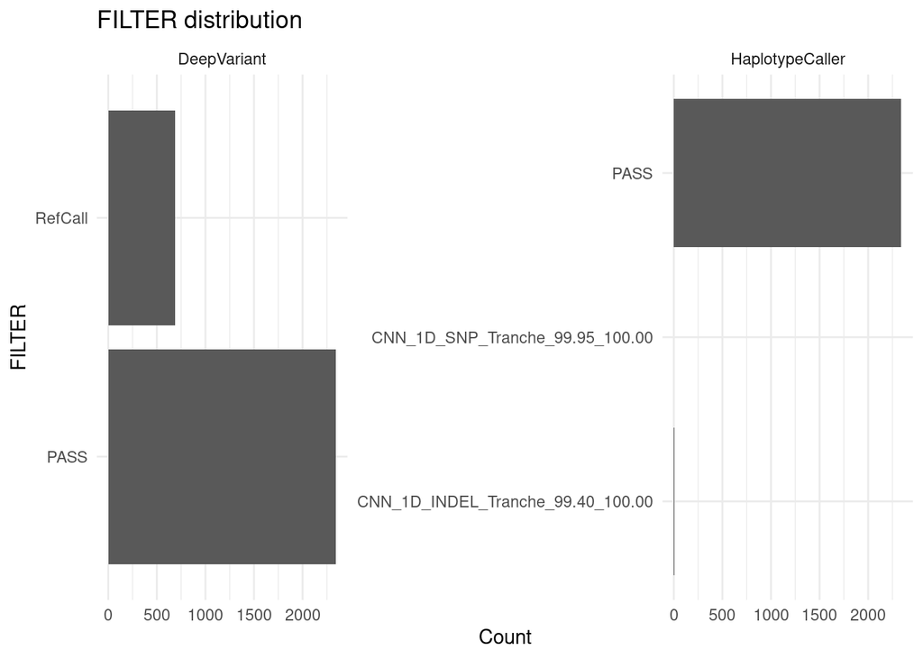

```r
hc_filter <- hc %>% count(FILTER, sort = TRUE) %>% mutate(caller = "HaplotypeCaller")
dv_filter <- dv %>% count(FILTER, sort = TRUE) %>% mutate(caller = "DeepVariant")

bind_rows(hc_filter, dv_filter) %>%
  ggplot(aes(x = FILTER, y = n)) +
  geom_col() +
  coord_flip() +
  facet_wrap(~caller, scales = "free_y") +
  theme_minimal() +
  labs(title = "FILTER distribution", x = "FILTER", y = "Count")
```

### 5.4 QUAL distribution

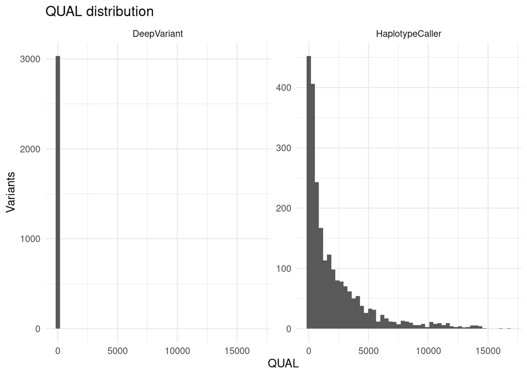

```r
qual_df <- bind_rows(
  hc %>% transmute(caller = "HaplotypeCaller", QUAL),
  dv %>% transmute(caller = "DeepVariant", QUAL)
) %>% filter(!is.na(QUAL))

ggplot(qual_df, aes(x = QUAL)) +
  geom_histogram(bins = 50) +
  facet_wrap(~caller, scales = "free_y") +
  theme_minimal() +
  labs(title = "QUAL distribution", x = "QUAL", y = "Variants")
```

## Is something looks wrong in this distribution?

### 5.5 Parse FORMAT metrics (DP, GQ, AD -> VAF)

```r
### 5.5 Parse FORMAT metrics (DP, GQ, AD -> VAF)

library(dplyr)
library(stringr)
library(tidyr)

# Robustly detect the CHROM column name
get_chrom_colname <- function(df){
  chrom_candidates <- c("#CHROM","CHROM","X.CHROM","X..CHROM","X.CHROM.")
  chrom_col <- intersect(chrom_candidates, names(df))[1]
  if (is.na(chrom_col)) {
    stop("Cannot find CHROM column. Available columns are: ", paste(names(df), collapse = ", "))
  }
  chrom_col
}

# Robustly detect the sample column name (assumes 1-sample VCF)
get_sample_colname <- function(df){
  known <- c("#CHROM","CHROM","X.CHROM","X..CHROM","X.CHROM.",
             "POS","ID","REF","ALT","QUAL","FILTER","INFO","FORMAT","var_key")
  candidates <- setdiff(names(df), known)
  if (length(candidates) == 0) stop("No sample column detected. Check your VCF table columns.")
  tail(candidates, 1)
}

parse_format_metrics <- function(df){
  chrom_col  <- get_chrom_colname(df)
  sample_col <- get_sample_colname(df)

  # Split FORMAT tags (GT:AD:DP:GQ:...)
  fmt_tags <- strsplit(as.character(df$FORMAT), ":", fixed = TRUE)

  # Split sample values using the same separator
  sample_vals <- strsplit(as.character(df[[sample_col]]), ":", fixed = TRUE)

  parsed <- lapply(seq_len(nrow(df)), function(i){
    tags <- fmt_tags[[i]]
    vals <- sample_vals[[i]]

    if (length(vals) < length(tags)) {
      vals <- c(vals, rep(NA, length(tags) - length(vals)))
    }

    out <- as.list(vals[seq_along(tags)])
    names(out) <- tags
    out
  })

  parsed_df <- bind_rows(parsed)

  # Keep key variant columns + parsed FORMAT fields
  out <- bind_cols(
    df %>%
      transmute(
        var_key,
        CHROM = .data[[chrom_col]],
        POS, REF, ALT, QUAL, FILTER, INFO
      ),
    parsed_df
  )

  # Convert numeric fields if present
  if ("DP" %in% names(out)) out$DP <- suppressWarnings(as.numeric(out$DP))
  if ("GQ" %in% names(out)) out$GQ <- suppressWarnings(as.numeric(out$GQ))

  # Compute VAF from AD if present (ref,alt)
  if ("AD" %in% names(out)) {
    ad_split <- strsplit(as.character(out$AD), ",", fixed = TRUE)
    out$AD_ref <- suppressWarnings(as.numeric(sapply(ad_split, function(x) if(length(x)>=1) x[1] else NA)))
    out$AD_alt <- suppressWarnings(as.numeric(sapply(ad_split, function(x) if(length(x)>=2) x[2] else NA)))
    out$VAF <- out$AD_alt / (out$AD_ref + out$AD_alt)
  }

  out
}

hc_m <- parse_format_metrics(hc) %>% mutate(caller = "HaplotypeCaller")
dv_m <- parse_format_metrics(dv) %>% mutate(caller = "DeepVariant")

metrics <- bind_rows(hc_m, dv_m)

# Show which technical FORMAT fields were found
setdiff(names(metrics), c("var_key","CHROM","POS","REF","ALT","QUAL","FILTER","INFO","caller"))
```

```
## [1] "GT"     "AD"     "DP"     "GQ"     "PL"     "AD_ref" "AD_alt" "VAF"
```

### 5.6 Compare DP, GQ, VAF distributions

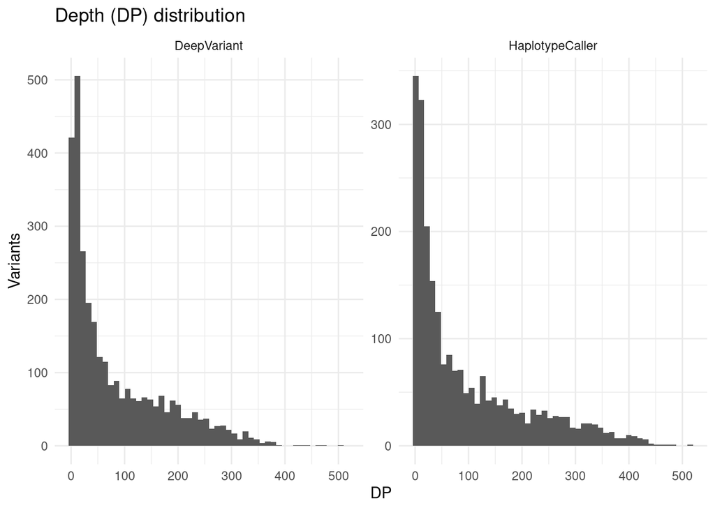

```r
if ("DP" %in% names(metrics)) {
  ggplot(metrics %>% filter(!is.na(DP)), aes(x = DP)) +
    geom_histogram(bins = 50) +
    facet_wrap(~caller, scales = "free_y") +
    theme_minimal() +
    labs(title = "Depth (DP) distribution", x = "DP", y = "Variants")
}
```

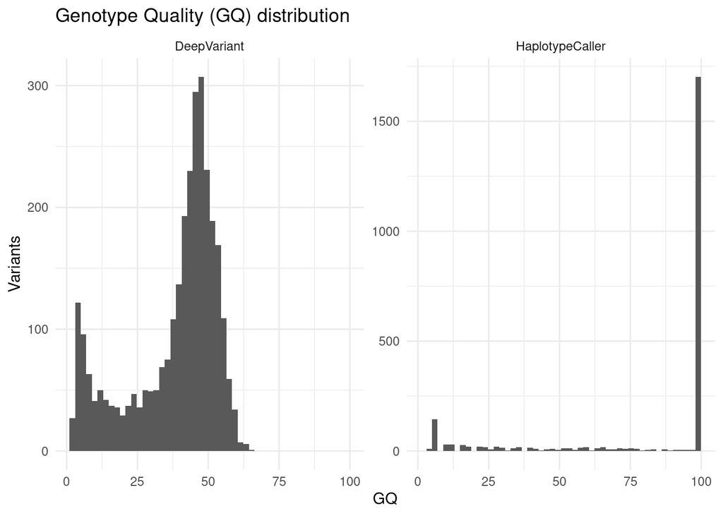

```r
if ("GQ" %in% names(metrics)) {
  ggplot(metrics %>% filter(!is.na(GQ)), aes(x = GQ)) +
    geom_histogram(bins = 50) +
    facet_wrap(~caller, scales = "free_y") +
    theme_minimal() +
    labs(title = "Genotype Quality (GQ) distribution", x = "GQ", y = "Variants")
}
```

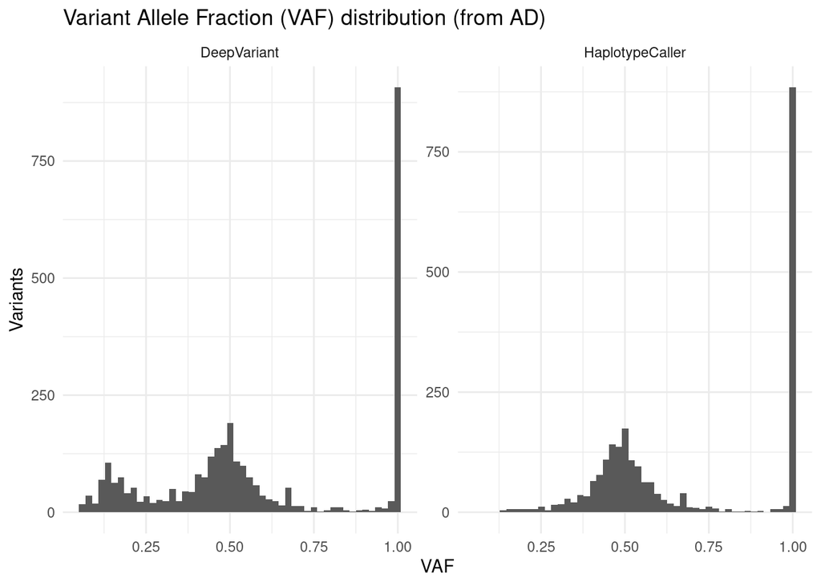

```r
if ("VAF" %in% names(metrics)) {
  ggplot(metrics %>% filter(!is.na(VAF)), aes(x = VAF)) +
    geom_histogram(bins = 50) +
    facet_wrap(~caller, scales = "free_y") +
    theme_minimal() +
    labs(title = "Variant Allele Fraction (VAF) distribution (from AD)", x = "VAF", y = "Variants")
}
```

### 5.7 Shared vs caller-unique variants

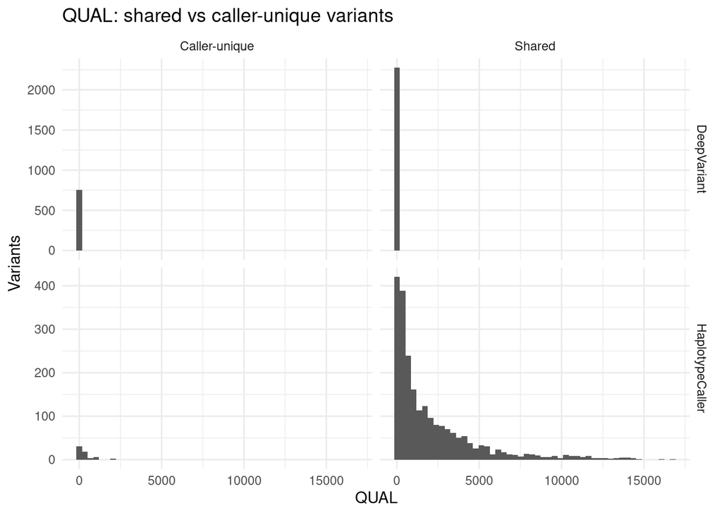

```r
label_shared_unique <- function(df_metrics, shared_keys){
  df_metrics %>% mutate(set = ifelse(var_key %in% shared_keys, "Shared", "Caller-unique"))
}

hc_su <- label_shared_unique(hc_m, shared_keys)
dv_su <- label_shared_unique(dv_m, shared_keys)

su <- bind_rows(hc_su, dv_su)

ggplot(su %>% filter(!is.na(QUAL)), aes(x = QUAL)) +
  geom_histogram(bins = 50) +
  facet_grid(caller ~ set, scales = "free_y") +
  theme_minimal() +
  labs(title = "QUAL: shared vs caller-unique variants", x = "QUAL", y = "Variants")
```

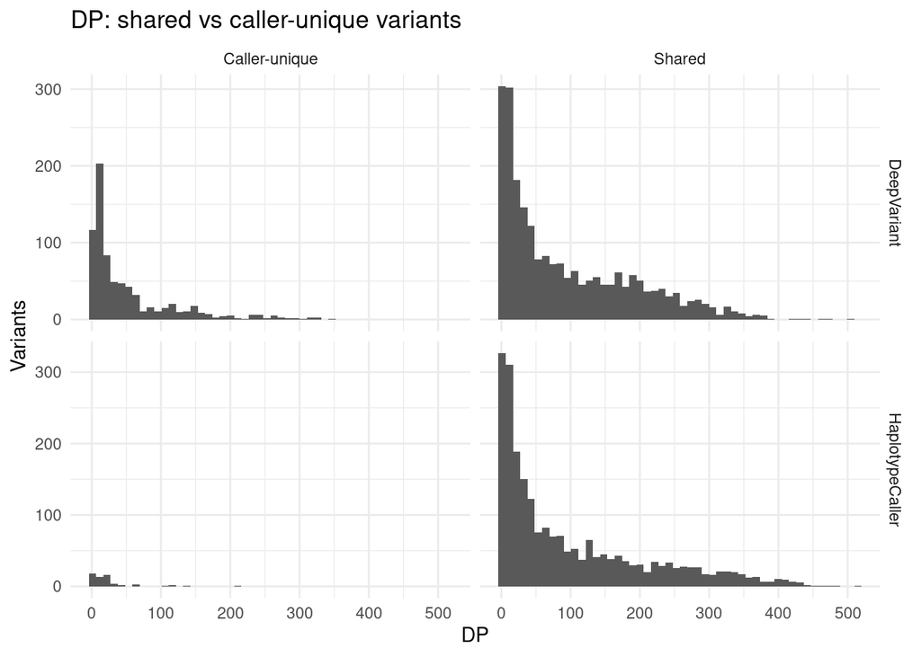

```r
if ("DP" %in% names(su)) {
  ggplot(su %>% filter(!is.na(DP)), aes(x = DP)) +
    geom_histogram(bins = 50) +
    facet_grid(caller ~ set, scales = "free_y") +
    theme_minimal() +
    labs(title = "DP: shared vs caller-unique variants", x = "DP", y = "Variants")
}
```

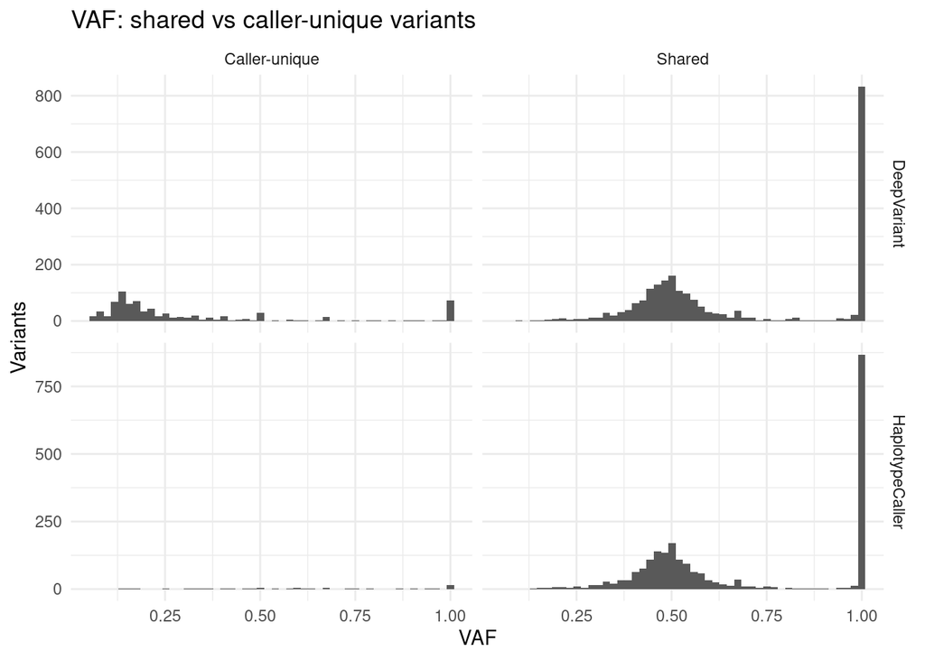

```r
if ("VAF" %in% names(su)) {
  ggplot(su %>% filter(!is.na(VAF)), aes(x = VAF)) +
    geom_histogram(bins = 50) +
    facet_grid(caller ~ set, scales = "free_y") +
    theme_minimal() +
    labs(title = "VAF: shared vs caller-unique variants", x = "VAF", y = "Variants")
}
```

### 5.8 Optional: Focus on a gene (e.g., PRF1)

```r
gene_of_interest <- "PRF1"

hc_gene <- hc_m %>% filter(grepl(gene_of_interest, INFO, ignore.case = TRUE))
dv_gene <- dv_m %>% filter(grepl(gene_of_interest, INFO, ignore.case = TRUE))

tibble(
  gene = gene_of_interest,
  hc_variants = n_distinct(hc_gene$var_key),
  dv_variants = n_distinct(dv_gene$var_key),
  shared = length(intersect(hc_gene$var_key, dv_gene$var_key))
)
```

```
## # A tibble: 1 × 4
##   gene  hc_variants dv_variants shared
##   <chr>       <int>       <int>  <int>
## 1 PRF1           10          10     10
```

### Notes for interpretation

- **Shared variants** are typically higher confidence (higher QUAL / higher DP).
- **Caller-unique variants** often occur at low coverage, low genotype quality, or harder regions.
- If a clinically relevant variant is present in only one callset, check: **FILTER**, **QUAL**, **DP**, **GQ**, and **AD/VAF** (if available).